# Movie Data Clustering Analysis

Shimin

2/10/2021

```r
# install.packages(c("cluster", "factoextra"))
library(cluster)
library(ggplot2)
library(factoextra)
library(fpc)
library(tidyverse)
library(caret)
library(class)
library(e1071)
```

# Data Preparation

In data preparation, I checked the NA value(no NUll value here in this dataset) and get dummy for categorical variable, normalized data for unbiased analysis.

```r
# Read csv file to movie dataset
movie <- readRDS('/Users/shiminyu/Downloads/movie_data.rds', refhook = NULL)
str(movie)
```

```
## tibble [395 × 11] (S3: spec_tbl_df/tbl_df/tbl/data.frame)
##  $ gross    : num [1:395] 9.13e+03 1.92e+08 3.07e+07 1.06e+08 1.73e+07 2.90e+04 4.26e+07 5.75e+06 2.60e+07 4.86e+07 ...
##  $ review   : Factor w/ 2 levels "NOT RECOMMENDED",..: 1 2 1 1 1 1 1 2 1 1 ...
##  $ budget   : num [1:395] 4.00e+06 5.00e+07 2.80e+07 1.10e+08 3.50e+06 5.00e+05 4.00e+07 2.00e+07 2.80e+07 1.25e+07 ...
##  $ screens  : num [1:395] 45 3306 2872 3470 2310 ...
##  $ sequel   : Factor w/ 2 levels "Main","Sequel": 1 2 1 2 2 1 1 1 1 1 ...
##  $ sentiment: num [1:395] 0 2 0 0 0 0 0 2 3 0 ...
##  $ views    : num [1:395] 3280543 583289 304861 452917 3145573 ...
##  $ likes    : num [1:395] 4632 3465 328 2429 12163 ...
##  $ dislikes : num [1:395] 425 61 34 132 610 7 419 197 419 532 ...
##  $ comments : num [1:395] 636 186 47 590 1082 ...
##  $ followers: num [1:395] 1120000 12350000 483000 568000 1923800 ...
##  - attr(*, "spec")=
##   .. cols(
##   ..   gross = col_double(),
##   ..   review = col_factor(levels = c("NOT RECOMMENDED", "RECOMMENDED"), ordered = FALSE, include_na = FALSE),
##   ..   budget = col_double(),
##   ..   screens = col_double(),
##   ..   sequel = col_factor(levels = c("Main", "Sequel"), ordered = FALSE, include_na = FALSE),
##   ..   sentiment = col_double(),
##   ..   views = col_double(),
##   ..   likes = col_double(),
##   ..   dislikes = col_double(),
##   ..   comments = col_double(),
##   ..   followers = col_double()
##   .. )
```

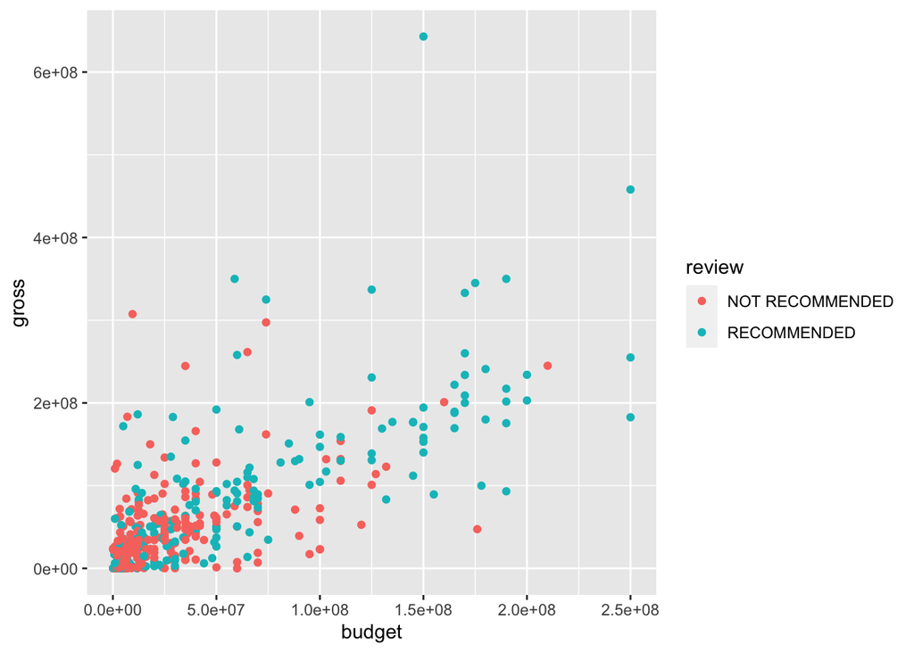

```r
# Transform variables of dataset
movie <- na.omit(movie)
movie_feature <- movie[,-2]
movie_feature <- fastDummies::dummy_cols(movie_feature,remove_first_dummy = TRUE)
movie_feature <- movie_feature[,-4]

# visualize the data
ggplot(movie,aes(x=budget,y=gross,color=review))+geom_point()
```

```r
# ggplot(movie,aes(x=budget,y=gross,color=sequel))+geom_point()

# Normalization
# All different numerical values are highly different so I need to normalize the dataset.
m <- apply(movie_feature,2,mean)
s <- apply(movie_feature,2,sd)
z <- scale(movie_feature,m,s)
```

# Hierarchical Clustering

Firstly, I use unsupervised learning to do classification. Hierarchical clustering does not perform well on this dataste and being extremely biased on prediction.

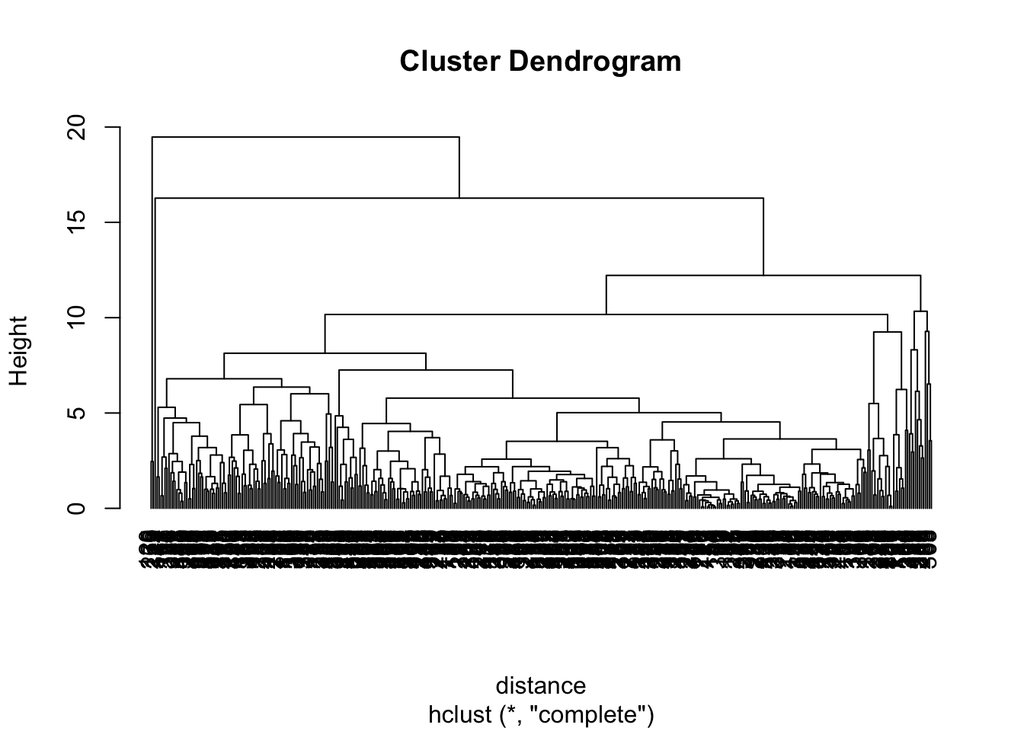

```r
# Calculating Euclidean Distance
distance <- dist(z)
#print(distance,digits=2)

# Cluster Dendrogram with complete linkage
hc.c <- hclust(distance)
plot(hc.c,hang = -1)
```

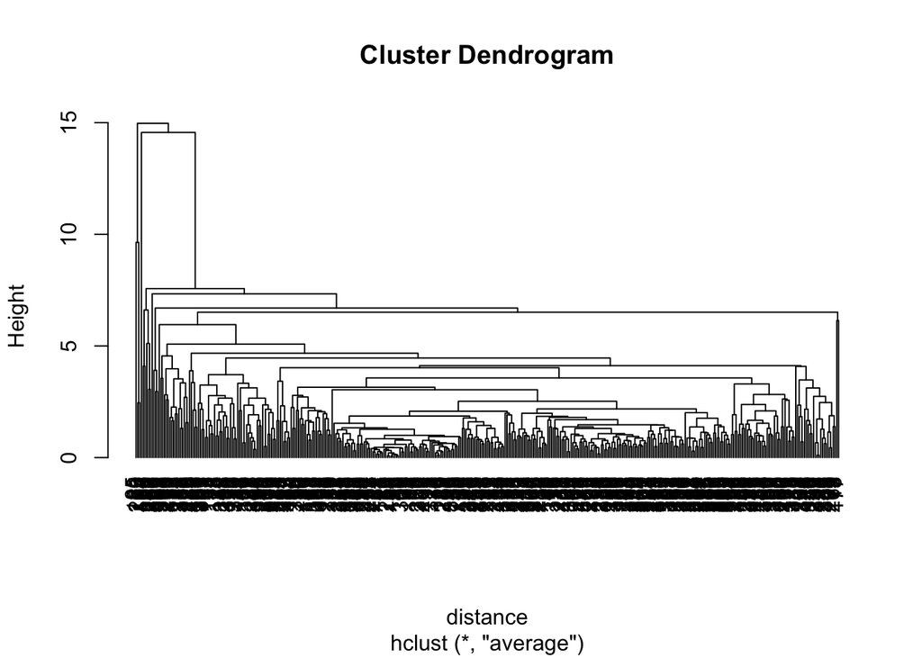

```r
# Cluster Dendrogram with Average Linkage
hc.a <- hclust(distance,method = 'average')
plot(hc.a,hang=-1)
```

```r
# Cluster Movie
movie.c <- cutree(hc.c,2)
movie.a <- cutree(hc.a,2)

# Check Accuracy of Clustering
table(movie$review,movie.c)
```

```
##                  movie.c
##                     1   2
##   NOT RECOMMENDED 214   0
##   RECOMMENDED     179   2
```

```r
table(movie$review,movie.a)
```

```
##                  movie.a
##                     1   2
##   NOT RECOMMENDED 213   1
##   RECOMMENDED     179   2
```

# K-Means Clustering

```r
km <- kmeans(z, centers = 2, nstart = 25)
km
```

```
## K-means clustering with 2 clusters of sizes 126, 269
##
## Cluster means:
##        gross     budget    screens   sentiment      views      likes   dislikes
## 1  0.9667257  0.9326709  0.7661111 -0.13844484  0.5349487  0.3978525  0.4781951
## 2 -0.4528157 -0.4368644 -0.3588476  0.06484777 -0.2505707 -0.1863547 -0.2239873
##     comments  followers sequel_Sequel
## 1  0.4803756  0.4249747     0.5768311
## 2 -0.2250086 -0.1990588    -0.2701885
##
## Clustering vector:
##   [1] 2 1 2 1 2 2 2 2 2 2 1 2 1 2 2 2 2 2 1 2 1 2 2 2 2 2 1 1 2 2 1 2 1 2 1 2 1
##  [38] 2 2 2 2 2 2 2 1 1 1 2 2 1 2 1 2 2 2 1 2 2 2 1 2 2 2 1 2 2 2 2 2 2 1 2 2 2
##  [75] 1 1 2 2 1 1 2 2 1 2 1 2 2 2 2 1 2 1 1 1 2 2 2 2 2 2 2 1 2 2 2 2 2 1 2 2 1
## [112] 2 2 2 2 2 2 1 1 1 2 2 2 2 1 2 2 1 2 2 2 2 2 1 2 2 2 2 2 2 1 2 2 2 2 2 2 2
## [149] 1 1 1 2 1 2 2 2 2 2 2 2 2 1 2 1 1 1 1 1 1 1 1 1 1 1 1 2 1 1 1 1 1 1 1 2 1
## [186] 1 2 2 1 2 1 2 2 2 2 2 2 1 2 2 2 2 1 2 2 1 2 2 2 2 2 2 2 2 2 2 2 1 1 2 2 1
## [223] 2 2 2 2 2 2 2 2 2 2 2 2 2 2 2 1 2 2 1 1 2 2 2 1 2 2 1 2 1 2 1 2 2 1 2 2 1
## [260] 2 2 1 2 2 1 2 2 1 2 2 1 2 2 2 2 2 2 2 2 2 2 1 2 2 1 1 2 1 2 1 2 2 2 2 2 2
## [297] 1 2 2 2 2 2 1 1 1 2 1 2 2 2 2 1 2 2 2 2 2 1 2 1 1 2 2 1 2 2 2 1 1 2 2 2 2
## [334] 2 2 1 1 2 1 2 2 2 2 2 2 2 1 1 2 2 1 1 1 2 2 1 2 1 2 2 2 2 2 2 2 1 2 2 2 1
## [371] 2 2 2 2 2 2 2 1 1 2 1 2 1 1 2 1 1 2 1 2 2 2 2 2 1
##
## Within cluster sum of squares by cluster:
## [1] 2212.454 1019.340
##  (between_SS / total_SS =  18.0 %)
##
## Available components:
##
## [1] "cluster"      "centers"      "totss"        "withinss"     "tot.withinss"
## [6] "betweenss"    "size"         "iter"         "ifault"
```

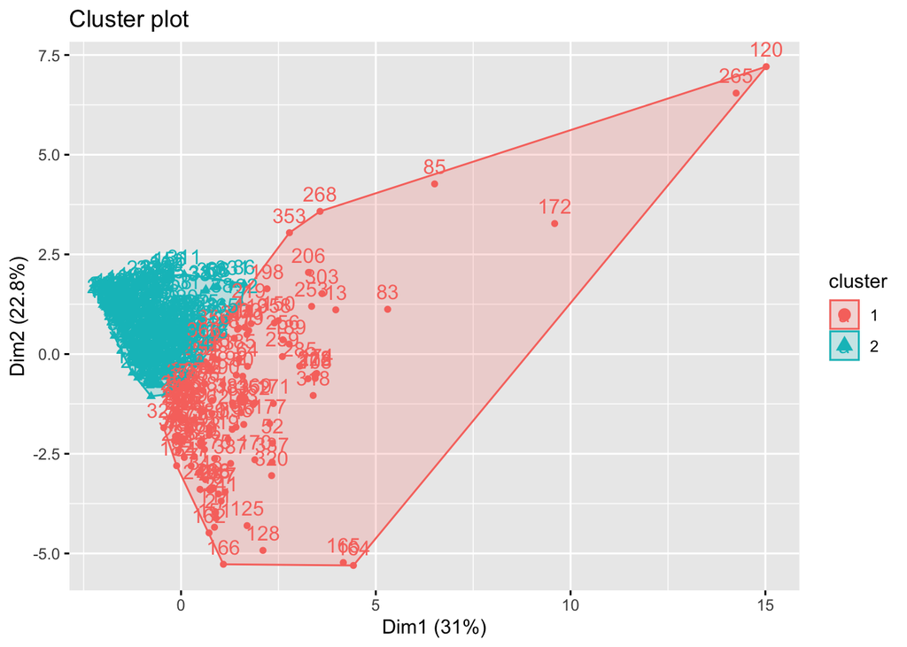

```r
fviz_cluster(km, data = movie_feature)
```

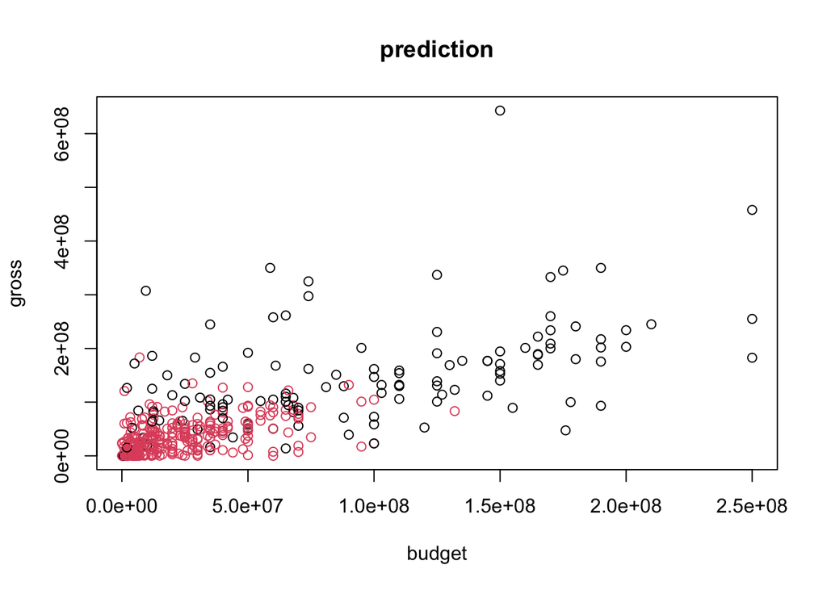

```r
plot(gross~budget,movie,col=km$cluster,main='prediction')
```

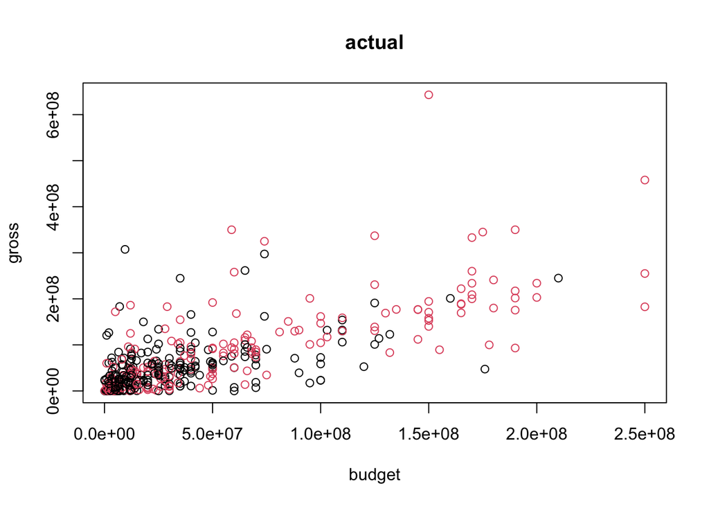

```r
plot(gross~budget,movie,col=movie$review,main='actual')
```

```r
table(movie$review,km$cluster)
```

```
##
##                     1   2
##   NOT RECOMMENDED  51 163
##   RECOMMENDED      75 106
```

# K-Medoids Clustering

```r
km2 <- pam(z,k=2)
km2
```

```
## Medoids:
##      ID      gross     budget    screens   sentiment      views      likes
## [1,]  8 -0.8341883 -0.5025820 -1.0455014 -0.13948100 -0.4476633 -0.3610856
## [2,] 41  0.1747786  0.4158146  0.7680379 -0.00892414 -0.3567927 -0.3020094
##        dislikes   comments  followers sequel_Sequel
## [1,] -0.3830714 -0.3599462 -0.6044530    -0.4795268
## [2,] -0.2571110 -0.1673835 -0.2471883    -0.4795268
## Clustering vector:
##   [1] 1 2 2 2 1 1 2 1 2 2 2 1 2 2 1 1 1 1 2 1 2 1 2 1 1 1 2 2 1 1 2 2 2 2 2 2 2
##  [38] 2 1 1 2 1 1 1 2 2 2 1 2 2 1 2 1 1 1 2 2 2 1 2 2 2 1 2 1 1 1 1 1 2 2 1 2 1
##  [75] 2 2 1 2 2 2 2 1 2 2 2 1 2 1 1 2 2 2 2 2 1 1 2 1 1 2 2 2 2 1 1 1 2 2 2 1 2
## [112] 1 1 1 2 1 1 2 1 2 1 1 1 1 2 1 1 2 1 1 1 2 2 2 1 1 2 2 2 1 2 2 1 1 1 1 1 1
## [149] 2 2 2 1 2 1 1 1 1 1 1 2 1 2 1 2 2 2 2 2 2 2 2 2 2 2 2 2 2 2 2 2 2 2 2 1 2
## [186] 2 2 2 2 2 2 2 2 2 1 2 2 2 1 2 2 2 1 1 2 2 1 2 2 2 2 2 1 1 1 1 1 2 2 1 2 2
## [223] 2 1 2 1 1 2 2 1 1 2 1 1 1 2 2 2 2 2 2 2 2 1 2 2 2 1 2 2 1 1 2 2 2 2 1 1 2
## [260] 2 2 2 2 1 2 2 2 1 2 2 2 2 1 2 1 2 1 2 1 1 1 2 1 2 2 2 2 2 1 2 2 2 1 1 1 1
## [297] 2 2 2 1 2 1 2 2 2 2 2 1 2 1 1 2 2 2 2 2 1 2 2 2 2 2 1 2 1 1 1 2 2 1 1 1 2
## [334] 2 2 2 2 1 2 1 2 2 2 1 1 1 2 2 2 1 2 2 1 2 1 1 1 2 2 2 2 1 2 2 2 2 2 2 1 2
## [371] 2 2 1 1 2 2 1 2 2 1 2 1 2 2 2 2 2 2 2 1 2 1 2 2 2
## Objective function:
##    build     swap
## 2.418080 2.386687
##
## Available components:
##  [1] "medoids"    "id.med"     "clustering" "objective"  "isolation"
##  [6] "clusinfo"   "silinfo"    "diss"       "call"       "data"
```

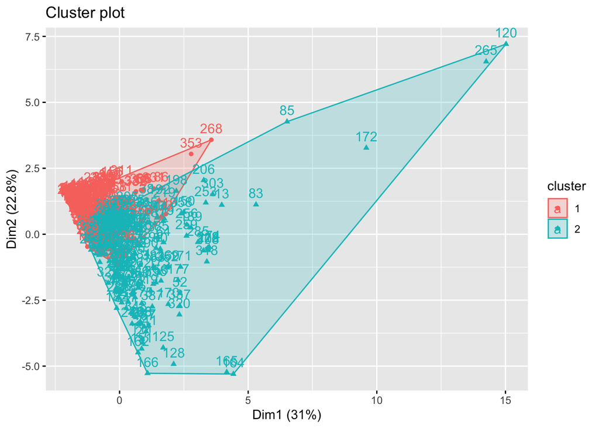

```r
fviz_cluster(km2, data = movie_feature)
```

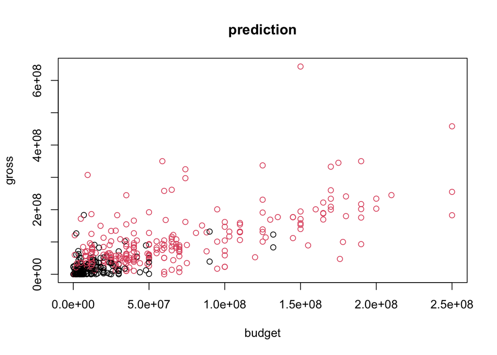

```r
plot(gross~budget,movie,col=km2$cluster,main='prediction')
```

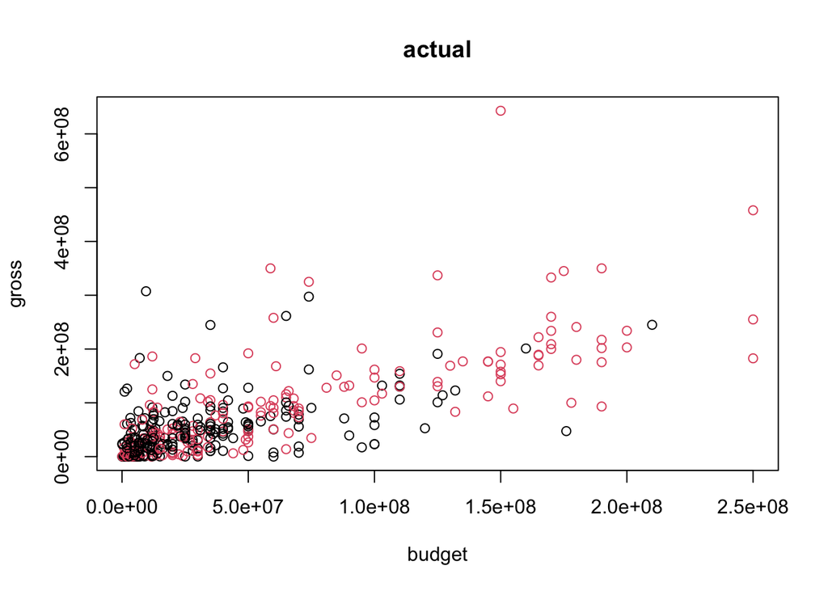

```r
plot(gross~budget,movie,col=movie$review,main='actual')
```

```r
table(movie$review,km2$clustering)
```

```
##
##                     1   2
##   NOT RECOMMENDED  86 128
##   RECOMMENDED      67 114
```

# Supervised Learning - KNN-Clustering

So far the unsupervised learning does not performed well here, so I tried supervised learning instead to do the clusteirng model.KNN clustering has higher accuracy in both training and test data than previous one. I split test and train data here to avoid overfitting issue.

```r
library(class)
train <- z[1:300,]
test <- z[301:395,]

cl <- movie[1:300,2]
cl <- as.vector(unlist(cl))
dim(train)
```

```
## [1] 300  10
```

```r
dim(test)
```

```
## [1] 95 10
```

```r
length(cl)
```

```
## [1] 300
```

```r
movie_pred <- knn(train,test,cl,k=19)
movie_pred2 <- knn(train,z,cl,k=19)
table(movie_pred,movie$review[301:395])
```

```
##
## movie_pred        NOT RECOMMENDED RECOMMENDED
##   NOT RECOMMENDED              44          12
##   RECOMMENDED                   9          30
```

```r
table(movie_pred2,movie$review)
```

```
##
## movie_pred2       NOT RECOMMENDED RECOMMENDED
##   NOT RECOMMENDED             180          70
##   RECOMMENDED                  34         111
```

# SVM Algorithm

For SVM, I will use the same train and test split in the previous method for comparison. SVM performed better than KNN in both train and test data. At this point of level, I will use SVM(Suport vector machine) as my final model for classification here.

```r
movie2 <- fastDummies::dummy_cols(movie,remove_first_dummy = TRUE)
movie2[,-12]
```

```
## # A tibble: 395 x 12
##     gross review budget screens sequel sentiment  views likes dislikes comments
##     <dbl> <fct>   <dbl>   <dbl> <fct>      <dbl>  <dbl> <dbl>    <dbl>    <dbl>
##  1 9.13e3 NOT R… 4.00e6      45 Main           0 3.28e6  4632      425      636
##  2 1.92e8 RECOM… 5.00e7    3306 Sequel         2 5.83e5  3465       61      186
##  3 3.07e7 NOT R… 2.80e7    2872 Main           0 3.05e5   328       34       47
##  4 1.06e8 NOT R… 1.10e8    3470 Sequel         0 4.53e5  2429      132      590
##  5 1.73e7 NOT R… 3.50e6    2310 Sequel         0 3.15e6 12163      610     1082
##  6 2.90e4 NOT R… 5.00e5    1507 Main           0 9.11e4   112        7        1
##  7 4.26e7 NOT R… 4.00e7    3158 Main           0 3.01e6  9595      419     1020
##  8 5.75e6 RECOM… 2.00e7     818 Main           2 1.85e6  2207      197      593
##  9 2.60e7 NOT R… 2.80e7    2714 Main           3 2.21e6  2210      419      382
## 10 4.86e7 NOT R… 1.25e7    2253 Main           0 5.22e6 11709      532      770
## # … with 385 more rows, and 2 more variables: followers <dbl>,
## #   sequel_Sequel <int>
```

```r
z1 <- as.data.frame(z)
z1$review <- movie$review
train1 <- z1[1:300,]
test1 <- z1[301:395,]
tuned <- tune(svm,review~.,data=train1,kernel='linear',ranges = list(cost = c(0.01,0.1,1,10,100)))
summary(tuned)
```

```
##
## Parameter tuning of 'svm':
##
## - sampling method: 10-fold cross validation
##
## - best parameters:
##  cost
##     1
##
## - best performance: 0.2966667
##
## - Detailed performance results:
##    cost     error dispersion
## 1 1e-02 0.3900000  0.1133660
## 2 1e-01 0.3166667  0.1068632
## 3 1e+00 0.2966667  0.1159502
## 4 1e+01 0.3000000  0.1077262
## 5 1e+02 0.3033333  0.1035780
```

```r
svmfit <- svm(review~.,data=train1,kernel='linear',cost = 10,scale=F)
summary(svmfit)
```

```
##
## Call:
## svm(formula = review ~ ., data = train1, kernel = "linear", cost = 10,
##     scale = F)
##
##
## Parameters:
##    SVM-Type:  C-classification
##  SVM-Kernel:  linear
##        cost:  10
##
## Number of Support Vectors:  191
##
##  ( 95 96 )
##
##
## Number of Classes:  2
##
## Levels:
##  NOT RECOMMENDED RECOMMENDED
```

```r
p <- predict(svmfit,test1,type='class')
table(p,test1$review)
```

```
##
## p                 NOT RECOMMENDED RECOMMENDED
##   NOT RECOMMENDED              45           4
##   RECOMMENDED                   8          38
```

```r
svm_pred <- predict(svmfit,z1,type='class')
table(svm_pred,z1$review)
```

```
##
## svm_pred          NOT RECOMMENDED RECOMMENDED
##   NOT RECOMMENDED             180          61
##   RECOMMENDED                  34         120
```

# Binary Logistic Regression for Exploration purpose

For the last model, I will apply logistic regression. I used this because I know previously that it has two classes and I could perform supervised learning on this dataset. The logistic model cannot directly predict classification but can offer me some insights on influential factors on the final prediction. Check summary of logistic model for further details.

```r
glmfit <- glm(review~.,family = 'binomial',data=train1)
glmpred <- predict(glmfit,test1)
head(as.data.frame(cbind(test1$review,
glmpred)))
```

```
##     V1    glmpred
## 301  1 -1.1937484
## 302  1 -0.4161783
## 303  2 -0.5959527
## 304  2  0.7593749
## 305  2  0.7538888
## 306  1 -1.0537901
```

```r
summary(glmfit)
```

```
##
## Call:
## glm(formula = review ~ ., family = "binomial", data = train1)
##
## Deviance Residuals:
##     Min       1Q   Median       3Q      Max
## -2.7884  -0.9116  -0.2671   0.9340   2.4980
##
## Coefficients:
##               Estimate Std. Error z value Pr(>|z|)
## (Intercept)   -0.08345    0.14460  -0.577 0.563867
## gross          1.29773    0.31237   4.154 3.26e-05 ***
## budget         0.59600    0.23976   2.486 0.012926 *
## screens       -0.69475    0.19140  -3.630 0.000284 ***
## sentiment      0.40719    0.17094   2.382 0.017217 *
## views          0.76520    0.28752   2.661 0.007783 **
## likes          2.07328    0.67279   3.082 0.002059 **
## dislikes      -1.36721    0.41720  -3.277 0.001049 **
## comments      -1.22848    0.58170  -2.112 0.034695 *
## followers     -0.22607    0.15432  -1.465 0.142921
## sequel_Sequel -0.86865    0.20564  -4.224 2.40e-05 ***
## ---
## Signif. codes:  0 '***' 0.001 '**' 0.01 '*' 0.05 '.' 0.1 ' ' 1
##
## (Dispersion parameter for binomial family taken to be 1)
##
##     Null deviance: 414.27  on 299  degrees of freedom
## Residual deviance: 319.65  on 289  degrees of freedom
## AIC: 341.65
##
## Number of Fisher Scoring iterations: 6
```